# Assignment 3 - Young People’s Survey

Egecan Esen

9/13/2020

## 0.1 Esoph Data

This is an analysis of esophogeal cancer data. Let’s take a look at what we are dealing with:

```r
esoph_data <- esoph
esoph_data %>% str()
```

```
## 'data.frame':    88 obs. of  5 variables:
##  $ agegp    : Ord.factor w/ 6 levels "25-34"<"35-44"<..: 1 1 1 1 1 1 1 1 1 1 ...
##  $ alcgp    : Ord.factor w/ 4 levels "0-39g/day"<"40-79"<..: 1 1 1 1 2 2 2 2 3 3 ...
##  $ tobgp    : Ord.factor w/ 4 levels "0-9g/day"<"10-19"<..: 1 2 3 4 1 2 3 4 1 2 ...
##  $ ncases   : num  0 0 0 0 0 0 0 0 0 0 ...
##  $ ncontrols: num  40 10 6 5 27 7 4 7 2 1 ...
```

```r
esoph_data %>% head(10)
```

```
##    agegp     alcgp    tobgp ncases ncontrols
## 1  25-34 0-39g/day 0-9g/day      0        40
## 2  25-34 0-39g/day    10-19      0        10
## 3  25-34 0-39g/day    20-29      0         6
## 4  25-34 0-39g/day      30+      0         5
## 5  25-34     40-79 0-9g/day      0        27
## 6  25-34     40-79    10-19      0         7
## 7  25-34     40-79    20-29      0         4
## 8  25-34     40-79      30+      0         7
## 9  25-34    80-119 0-9g/day      0         2
## 10 25-34    80-119    10-19      0         1
```

There are 5 columns and 88 observations in this dataframe.

The columns contain information about `agegp` Age Group, `alcgp` Alcohol Consumption, `tbcgp` Tobacco Consumption, `ncases` Number of Cases and `ncontrols` Number of controls.

Let’s look at the summary data of these groups:

```r
esoph_data %>% summary()
```

```
##    agegp          alcgp         tobgp        ncases         ncontrols
##  25-34:15   0-39g/day:23   0-9g/day:24   Min.   : 0.000   Min.   : 1.00
##  35-44:15   40-79    :23   10-19   :24   1st Qu.: 0.000   1st Qu.: 3.00
##  45-54:16   80-119   :21   20-29   :20   Median : 1.000   Median : 6.00
##  55-64:16   120+     :21   30+     :20   Mean   : 2.273   Mean   :11.08
##  65-74:15                                3rd Qu.: 4.000   3rd Qu.:14.00
##  75+  :11                                Max.   :17.000   Max.   :60.00
```

We can see that the age groups are divided into 6 categories that are very close in terms of their numbers of occurrence. Alcohol and tobacco consumption are divided into 4 groups as well. Number of cases ranges from 0 to 17, however at least half of them are less than or equal to 1 and their average is only 2.273. This means higher number of cases are rare. Number of controls ranges from 1 to 60 and its mean is again, on the lower end, which is 11.08.

### 0.1.1 Analyzing the Effect of Belonging to Different Age Groups

Let’s look at how the age group an individual belongs to affect his or her chances of having cancer:

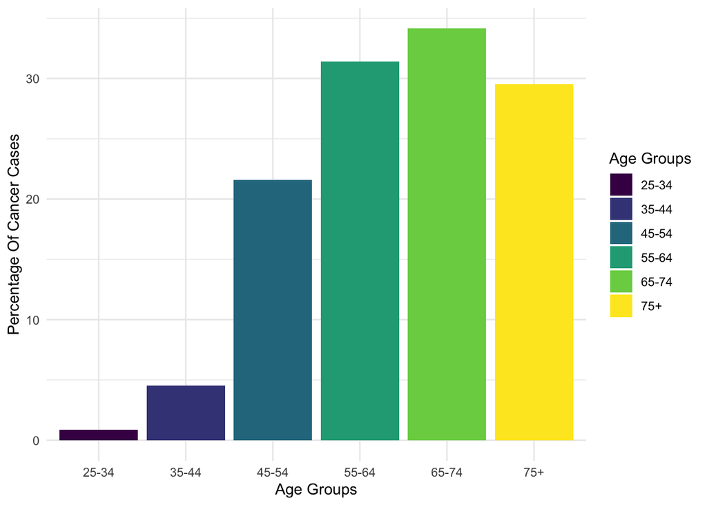

```r
age <- esoph_data %>%
  group_by(agegp) %>%
  mutate(tcases = sum(ncases),tcontrols=sum(ncontrols),npercentage=100*ncases/tcontrols)

ggplot(age, aes(x=agegp, y=npercentage,fill = agegp)) +
   geom_bar(stat="identity") +
   labs(x= 'Age Groups', y= 'Percentage Of Cancer Cases') +
   theme_minimal() +
   guides(fill=guide_legend(title="Age Groups"))
```

Here we can see that as the age increases, percentage of cancer cases also increases. After the age of 75, there are less observations and the data are less reliable. It may be because the people who develop cancer before the age of 75 are more likely to die before the age of 75.

### 0.1.2 Analyzing the Effect of Alcohol Consumption Level

Let’s see how the amount of alcohol one drinks affects his or her chances of developing esophageal cancer:

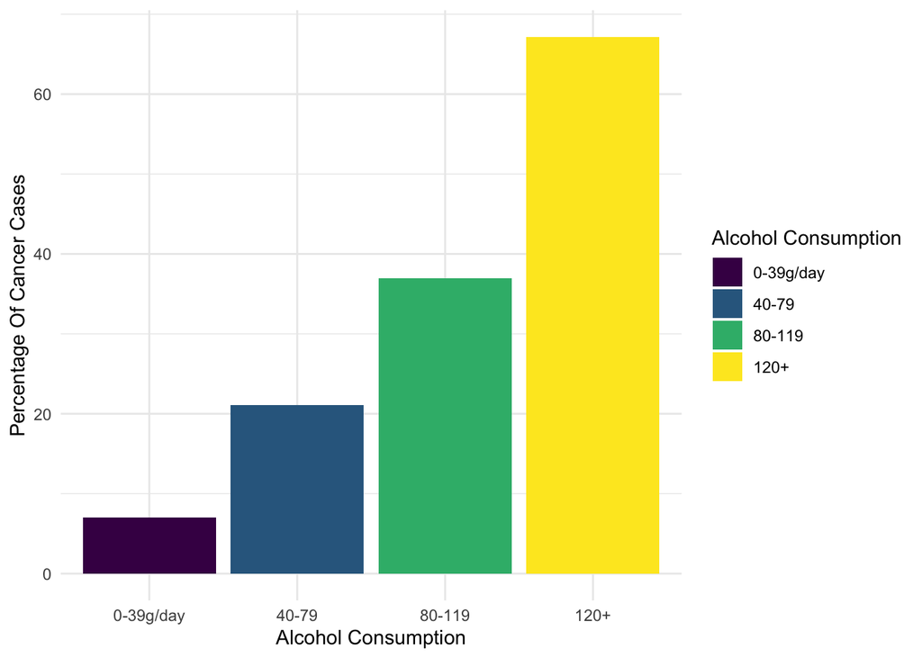

```r
alcohol <- esoph_data %>%
  group_by(alcgp) %>%
  mutate(tcontrols=sum(ncontrols),npercentage=100*ncases/tcontrols)

ggplot(alcohol, aes(x=alcgp, y=npercentage,fill = alcgp)) +
   geom_bar(stat="identity") +
   labs(x= 'Alcohol Consumption', y= 'Percentage Of Cancer Cases') +
   theme_minimal() +
   guides(fill=guide_legend(title="Alcohol Consumption"))
```

People who drink more are more likely to develop esophageal cancer.

### 0.1.3 Analyzing the Effect of Tobacco Consumption Level

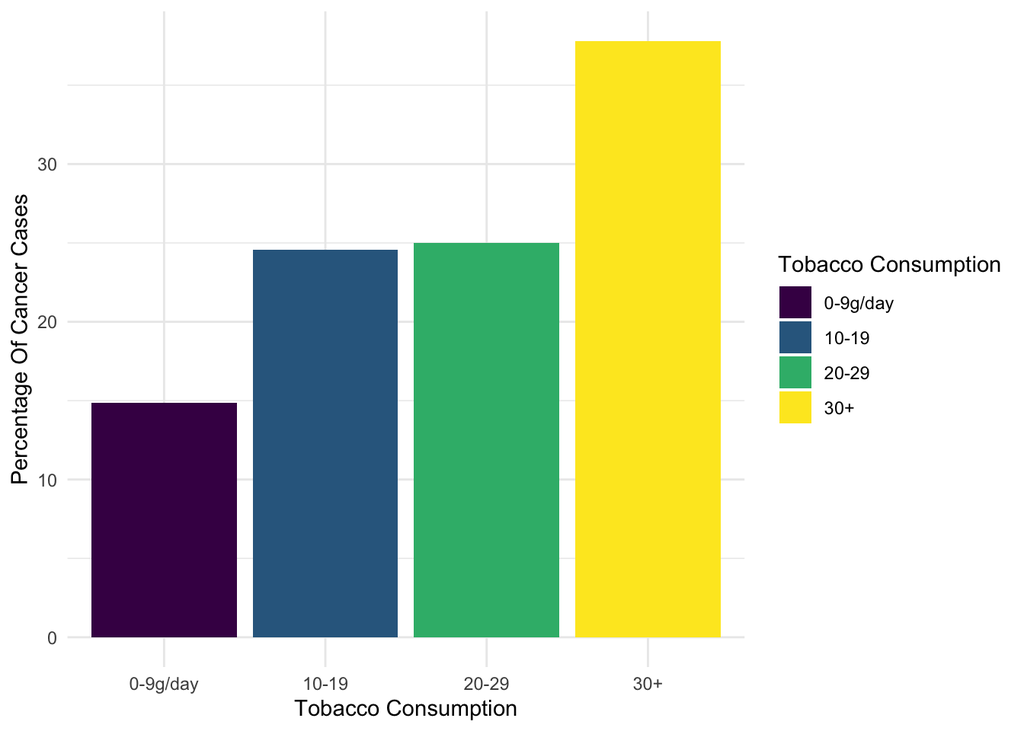

```r
tobacco <- esoph_data %>%
  group_by(tobgp) %>%
  mutate(tcontrols=sum(ncontrols),npercentage=100*ncases/tcontrols)

ggplot(tobacco, aes(x=tobgp, y=npercentage,fill = tobgp)) +
   geom_bar(stat="identity") +
   labs(x= 'Tobacco Consumption', y= 'Percentage Of Cancer Cases') +
   theme_minimal() +
   guides(fill=guide_legend(title="Tobacco Consumption"))
```

People who smoke more are more likely to develop esophageal cancer. However, it must be said that the differences in cancer risk are less that the other categories. This might be interpreted as, the number of cigarette one smokes matters less in terms of probability of developing cancer than the amount of alcohol consumed. Just smoking any cigarettes increases ones chances of developing cancer a lot.

### 0.1.4 Detailed Analysis of Alcohol and Tobacco Consumption’s Effect in Different Age Groups

Let’s analyze alcohol and tobacco consumption’s effect in each different age group individally:

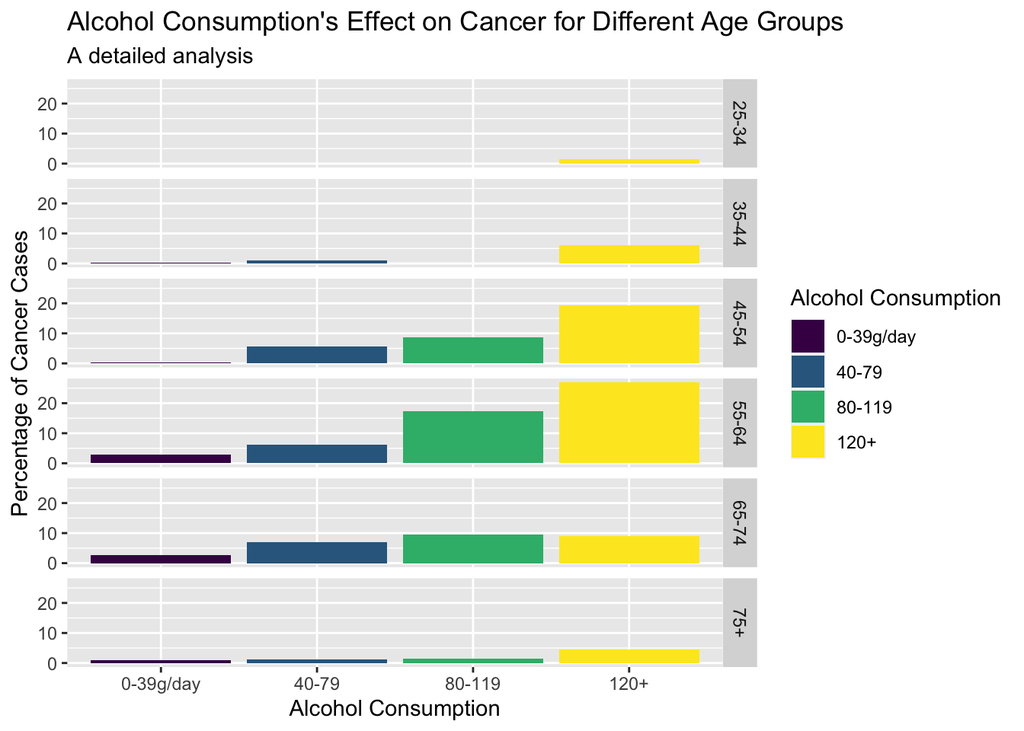

```r
age_alcohol <- age %>%
  group_by(alcgp) %>%
  mutate(sum_controls=sum(ncontrols)) %>%
  mutate(alc_percentage = 100* ncases/sum_controls)
age_alcohol %>%
  ggplot() +
  geom_bar(stat= "identity", aes(x=alcgp, y = alc_percentage, fill=alcgp)) +
  facet_grid(agegp ~ .) +
  labs(title="Alcohol Consumption's Effect on Cancer for Different Age Groups", subtitle="A detailed analysis", x="Alcohol Consumption", y="Percentage of Cancer Cases") +
  guides(fill=guide_legend(title="Alcohol Consumption"))
```

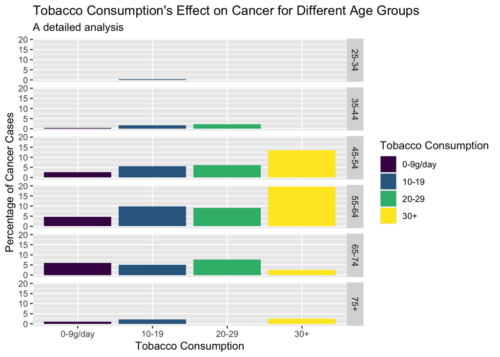

```r
age_tobacco <- age %>%
  group_by(tobgp) %>%
  mutate(sum_controls=sum(ncontrols)) %>%
  mutate(tob_percentage = 100* ncases/sum_controls)

age_tobacco %>%
  ggplot() +
  geom_bar(stat= "identity", aes(x=tobgp, y = tob_percentage, fill=tobgp)) +
  facet_grid(agegp ~ .) +
  labs(title="Tobacco Consumption's Effect on Cancer for Different Age Groups", subtitle="A detailed analysis", x="Tobacco Consumption", y="Percentage of Cancer Cases") +
  guides(fill=guide_legend(title="Tobacco Consumption"))
```

From these two graphs, it can be seen that the age groups 45-54, 55-64 and 65-74 are the groups that develop cancer most often.

Also, the effects of increased use of alcohol and tobacco are most apparent and effective in those age groups.

## 0.2 Young People Survey Data

First, let’s read the data and get the necessary columns:

```r
yps_data<-read.csv("responses.csv")
yps_data <- yps_data[,32:63]
```

Let’s take a look at the data:

```r
yps_data %>% str()
```

```
## 'data.frame':    1010 obs. of  32 variables:
##  $ History               : int  1 1 1 4 3 5 3 5 3 3 ...
##  $ Psychology            : int  5 3 2 4 2 3 3 2 2 2 ...
##  $ Politics              : int  1 4 1 5 3 4 1 3 1 3 ...
##  $ Mathematics           : int  3 5 5 4 2 2 1 1 1 3 ...
##  $ Physics               : int  3 2 2 1 2 3 1 1 1 1 ...
##  $ Internet              : int  5 4 4 3 2 4 2 5 1 5 ...
##  $ PC                    : int  3 4 2 1 2 4 1 4 1 1 ...
##  $ Economy.Management    : int  5 5 4 2 2 1 3 1 1 4 ...
##  $ Biology               : int  3 1 1 3 3 4 5 2 3 2 ...
##  $ Chemistry             : int  3 1 1 3 3 4 5 2 1 1 ...
##  $ Reading               : int  3 4 5 5 5 3 3 2 5 4 ...
##  $ Geography             : int  3 4 2 4 2 3 3 3 1 4 ...
##  $ Foreign.languages     : int  5 5 5 4 3 4 4 4 1 5 ...
##  $ Medicine              : int  3 1 2 2 3 4 5 1 1 1 ...
```

[output cut: 18 more lines]

```r
yps_data %>% summary()
```

```
##     History        Psychology       Politics      Mathematics
##  Min.   :1.000   Min.   :1.000   Min.   :1.000   Min.   :1.000
##  1st Qu.:2.000   1st Qu.:2.000   1st Qu.:1.000   1st Qu.:1.000
##  Median :3.000   Median :3.000   Median :2.000   Median :2.000
##  Mean   :3.207   Mean   :3.138   Mean   :2.596   Mean   :2.335
##  3rd Qu.:4.000   3rd Qu.:4.000   3rd Qu.:4.000   3rd Qu.:3.000
##  Max.   :5.000   Max.   :5.000   Max.   :5.000   Max.   :5.000
##  NA's   :2       NA's   :5       NA's   :1       NA's   :3
##     Physics         Internet           PC        Economy.Management
##  Min.   :1.000   Min.   :1.000   Min.   :1.000   Min.   :1.000
##  1st Qu.:1.000   1st Qu.:4.000   1st Qu.:2.000   1st Qu.:1.000
##  Median :2.000   Median :4.000   Median :3.000   Median :2.000
##  Mean   :2.065   Mean   :4.176   Mean   :3.136   Mean   :2.644
##  3rd Qu.:3.000   3rd Qu.:5.000   3rd Qu.:4.000   3rd Qu.:4.000
##  Max.   :5.000   Max.   :5.000   Max.   :5.000   Max.   :5.000
##  NA's   :3       NA's   :4       NA's   :6       NA's   :5
##     Biology        Chemistry        Reading        Geography
##  Min.   :1.000   Min.   :1.000   Min.   :1.000   Min.   :1.000
##  1st Qu.:2.000   1st Qu.:1.000   1st Qu.:2.000   1st Qu.:2.000
##  Median :2.000   Median :2.000   Median :3.000   Median :3.000
##  Mean   :2.665   Mean   :2.165   Mean   :3.159   Mean   :3.083
##  3rd Qu.:4.000   3rd Qu.:3.000   3rd Qu.:5.000   3rd Qu.:4.000
##  Max.   :5.000   Max.   :5.000   Max.   :5.000   Max.   :5.000
##  NA's   :6       NA's   :10      NA's   :6       NA's   :9
##  Foreign.languages    Medicine          Law             Cars
##  Min.   :1.000     Min.   :1.000   Min.   :1.000   Min.   :1.000
##  1st Qu.:3.000     1st Qu.:1.000   1st Qu.:1.000   1st Qu.:1.000
##  Median :4.000     Median :2.000   Median :2.000   Median :3.000
##  Mean   :3.778     Mean   :2.516   Mean   :2.257   Mean   :2.687
##  3rd Qu.:5.000     3rd Qu.:3.000   3rd Qu.:3.000   3rd Qu.:4.000
##  Max.   :5.000     Max.   :5.000   Max.   :5.000   Max.   :5.000
##  NA's   :5         NA's   :5       NA's   :1       NA's   :4
##  Art.exhibitions    Religion     Countryside..outdoors    Dancing
##  Min.   :1.00    Min.   :1.000   Min.   :1.000         Min.   :1.000
##  1st Qu.:1.00    1st Qu.:1.000   1st Qu.:3.000         1st Qu.:1.000
##  Median :2.00    Median :2.000   Median :4.000         Median :2.000
##  Mean   :2.59    Mean   :2.273   Mean   :3.687         Mean   :2.462
##  3rd Qu.:4.00    3rd Qu.:3.000   3rd Qu.:5.000         3rd Qu.:4.000
##  Max.   :5.00    Max.   :5.000   Max.   :5.000         Max.   :5.000
##  NA's   :6       NA's   :3       NA's   :7             NA's   :3
```

[output cut: 9 more lines]

```
##  Min.   :1.000   Min.   :1.000   Min.   :1.000   Min.   :1.000
##  1st Qu.:1.000   1st Qu.:1.000   1st Qu.:2.000   1st Qu.:2.000
##  Median :1.000   Median :2.000   Median :3.000   Median :3.000
##  Mean   :1.907   Mean   :2.362   Mean   :3.277   Mean   :3.234
##  3rd Qu.:3.000   3rd Qu.:3.000   3rd Qu.:4.000   3rd Qu.:4.000
##  Max.   :5.000   Max.   :5.000   Max.   :5.000   Max.   :5.000
##  NA's   :7       NA's   :2       NA's   :2       NA's   :6
##     Theatre      Fun.with.friends Adrenaline.sports      Pets
##  Min.   :1.000   Min.   :2.000    Min.   :1.000     Min.   :1.000
##  1st Qu.:2.000   1st Qu.:4.000    1st Qu.:2.000     1st Qu.:2.000
##  Median :3.000   Median :5.000    Median :3.000     Median :4.000
##  Mean   :3.025   Mean   :4.558    Mean   :2.948     Mean   :3.335
##  3rd Qu.:4.000   3rd Qu.:5.000    3rd Qu.:4.000     3rd Qu.:5.000
##  Max.   :5.000   Max.   :5.000    Max.   :5.000     Max.   :5.000
##  NA's   :8       NA's   :4        NA's   :3         NA's   :4
```

```r
yps_data %>% glimpse()
```

```
## Rows: 1,010
## Columns: 32
## $ History                <int> 1, 1, 1, 4, 3, 5, 3, 5, 3, 3, 3, 2, 4, 2, 2, 5…
## $ Psychology             <int> 5, 3, 2, 4, 2, 3, 3, 2, 2, 2, 3, 2, 4, 2, 5, 5…
## $ Politics               <int> 1, 4, 1, 5, 3, 4, 1, 3, 1, 3, 3, 5, 4, 1, 1, 3…
## $ Mathematics            <int> 3, 5, 5, 4, 2, 2, 1, 1, 1, 3, 2, 1, 1, 1, 1, 3…
## $ Physics                <int> 3, 2, 2, 1, 2, 3, 1, 1, 1, 1, 1, 1, 1, 1, 1, 3…
## $ Internet               <int> 5, 4, 4, 3, 2, 4, 2, 5, 1, 5, 4, 5, 3, 3, 4, 4…
## $ PC                     <int> 3, 4, 2, 1, 2, 4, 1, 4, 1, 1, 5, 4, 2, 3, 2, 5…
## $ Economy.Management     <int> 5, 5, 4, 2, 2, 1, 3, 1, 1, 4, 3, 1, 1, 3, 3, 3…
## $ Biology                <int> 3, 1, 1, 3, 3, 4, 5, 2, 3, 2, 2, 1, 5, 1, 2, 5…
## $ Chemistry              <int> 3, 1, 1, 3, 3, 4, 5, 2, 1, 1, 1, 1, 5, 1, 1, 2…
## $ Reading                <int> 3, 4, 5, 5, 5, 3, 3, 2, 5, 4, 3, 3, 5, 4, 4, 3…
## $ Geography              <int> 3, 4, 2, 4, 2, 3, 3, 3, 1, 4, 3, 5, 3, 1, 1, 3…
## $ Foreign.languages      <int> 5, 5, 5, 4, 3, 4, 4, 4, 1, 5, 5, 2, 5, 5, 3, 4…
```

[output cut: 19 more lines]

This is a dataframe of a survey of young people’s interest levels of different interest areas. We can see that they are ranked from 1 to 5 and there are some NA cases.We need to clean up the data a little bit:

```r
yps <- yps_data[complete.cases(yps_data),]
colSums(is.na(yps))
```

```
##                History             Psychology               Politics
##                      0                      0                      0
##            Mathematics                Physics               Internet
##                      0                      0                      0
##                     PC     Economy.Management                Biology
##                      0                      0                      0
##              Chemistry                Reading              Geography
##                      0                      0                      0
##      Foreign.languages               Medicine                    Law
##                      0                      0                      0
##                   Cars        Art.exhibitions               Religion
##                      0                      0                      0
##  Countryside..outdoors                Dancing    Musical.instruments
##                      0                      0                      0
##                Writing          Passive.sport           Active.sport
##                      0                      0                      0
##              Gardening            Celebrities               Shopping
##                      0                      0                      0
## Science.and.technology                Theatre       Fun.with.friends
##                      0                      0                      0
##      Adrenaline.sports                   Pets
##                      0                      0
```

We can see that no NA cases are present now.

### 0.2.1 Principal Component Analysis

Principal Component Analysis of the data will tell us about how each variable explains the data. Let’s take a look at some of the important of components and graph them:

```r
yps_pca <- princomp(as.matrix(yps),cor=T)
summary(yps_pca,loadings=TRUE)
```

```
## Importance of components:
##                           Comp.1    Comp.2     Comp.3     Comp.4     Comp.5
## Standard deviation     2.0433958 1.8069970 1.60438109 1.46391156 1.26463164
## Proportion of Variance 0.1304833 0.1020387 0.08043871 0.06696991 0.04997791
## Cumulative Proportion  0.1304833 0.2325220 0.31296072 0.37993063 0.42990854
##                            Comp.6     Comp.7     Comp.8     Comp.9    Comp.10
## Standard deviation     1.18461175 1.06955650 1.05602251 1.04363010 1.00633062
## Proportion of Variance 0.04385328 0.03574847 0.03484949 0.03403637 0.03164692
## Cumulative Proportion  0.47376182 0.50951029 0.54435978 0.57839615 0.61004306
##                           Comp.11    Comp.12    Comp.13    Comp.14    Comp.15
## Standard deviation     0.95951254 0.93789360 0.93168719 0.89503805 0.87262765
## Proportion of Variance 0.02877076 0.02748889 0.02712628 0.02503416 0.02379622
## Cumulative Proportion  0.63881382 0.66630271 0.69342899 0.71846315 0.74225937
##                           Comp.16   Comp.17    Comp.18    Comp.19    Comp.20
## Standard deviation     0.85510068 0.8329419 0.80296355 0.78632469 0.76747805
## Proportion of Variance 0.02284991 0.0216810 0.02014845 0.01932208 0.01840695
## Cumulative Proportion  0.76510928 0.7867903 0.80693874 0.82626082 0.84466777
##                           Comp.21    Comp.22    Comp.23    Comp.24    Comp.25
## Standard deviation     0.74821762 0.72513227 0.71054805 0.70905599 0.69087699
## Proportion of Variance 0.01749468 0.01643178 0.01577745 0.01571126 0.01491597
## Cumulative Proportion  0.86216245 0.87859422 0.89437168 0.91008294 0.92499891
##                           Comp.26    Comp.27    Comp.28   Comp.29     Comp.30
## Standard deviation     0.65750430 0.64296368 0.60888823 0.5954011 0.551814415
## Proportion of Variance 0.01350975 0.01291882 0.01158578 0.0110782 0.009515598
## Cumulative Proportion  0.93850866 0.95142748 0.96301326 0.9740915 0.983607058
##                            Comp.31     Comp.32
## Standard deviation     0.539017589 0.483770803
## Proportion of Variance 0.009079374 0.007313568
## Cumulative Proportion  0.992686432 1.000000000
##
## Loadings:
##                        Comp.1 Comp.2 Comp.3 Comp.4 Comp.5 Comp.6 Comp.7 Comp.8
## History                 0.196         0.184  0.243  0.130  0.243  0.142  0.194
## Psychology              0.244                0.119  0.112        -0.102
## Politics                0.131  0.202  0.255  0.204  0.270  0.153        -0.108
## Mathematics                    0.295 -0.126  0.133        -0.309 -0.220 -0.273
## Physics                        0.344 -0.241  0.136        -0.155 -0.151 -0.151
## Internet                       0.237  0.127               -0.400         0.370
## PC                             0.377               -0.134 -0.291  0.137  0.144
## Economy.Management             0.174  0.306         0.214 -0.182 -0.166 -0.288
```

[output cut: 141 more lines]

```
## Religion               -0.111
## Countryside..outdoors
## Dancing
## Musical.instruments
## Writing                         0.150
## Passive.sport
## Active.sport
## Gardening
## Celebrities
## Shopping                0.134
## Science.and.technology
## Theatre                -0.175   0.161
## Fun.with.friends
## Adrenaline.sports
## Pets
```

```r
yps_pca
```

```
## Call:
## princomp(x = as.matrix(yps), cor = T)
##
## Standard deviations:
##    Comp.1    Comp.2    Comp.3    Comp.4    Comp.5    Comp.6    Comp.7    Comp.8
## 2.0433958 1.8069970 1.6043811 1.4639116 1.2646316 1.1846118 1.0695565 1.0560225
##    Comp.9   Comp.10   Comp.11   Comp.12   Comp.13   Comp.14   Comp.15   Comp.16
## 1.0436301 1.0063306 0.9595125 0.9378936 0.9316872 0.8950381 0.8726277 0.8551007
##   Comp.17   Comp.18   Comp.19   Comp.20   Comp.21   Comp.22   Comp.23   Comp.24
## 0.8329419 0.8029636 0.7863247 0.7674780 0.7482176 0.7251323 0.7105481 0.7090560
##   Comp.25   Comp.26   Comp.27   Comp.28   Comp.29   Comp.30   Comp.31   Comp.32
## 0.6908770 0.6575043 0.6429637 0.6088882 0.5954011 0.5518144 0.5390176 0.4837708
##
##  32  variables and  886 observations.
```

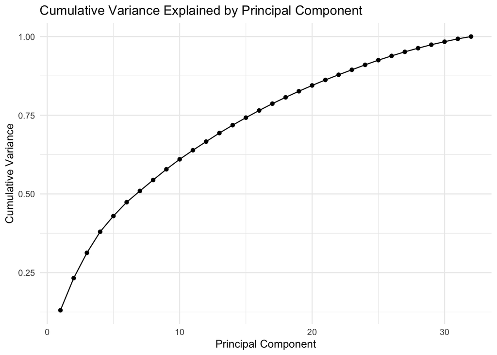

```r
ggplot(data.frame(pc=1:length(yps_pca$sdev), cum_var= cumsum(yps_pca$sdev^2/sum(yps_pca$sdev^2))), aes(x=pc,y=cum_var)) + geom_point() + geom_line() + theme_minimal() + labs(title= "Cumulative Variance Explained by Principal Component", x= "Principal Component", y = "Cumulative Variance")
```

It can be seen that 2 PC’s can explain almost 25% of the variance, 7 PC’s can explain almost 50% of the variance and 15 PC’s explain almost 75% of the variance.

I prefer to keep all the PC’s in my further analysis even though the last 12.5% of the variance is explained by 11 PC’s which makes them less important compared to other components.

### 0.2.2 Multidimensional Scaling

Let’s put the data in a distance matrix to see which interests are related to each other.

```r
set.seed(27)
#Normalize the correlations
dist <- 1-cor(yps)
yps_mds <- cmdscale(dist,k=2)
colnames(yps_mds) <- c("x","y")
yps_mds
```

```
##                                  x            y
## History                 0.06372563  0.012956654
## Psychology              0.23826552 -0.024422880
## Politics               -0.14749496  0.107881476
## Mathematics            -0.32345626 -0.297702691
## Physics                -0.32464296 -0.499240678
## Internet               -0.43673303  0.187118496
## PC                     -0.58516404 -0.107666761
## Economy.Management     -0.30422083  0.383264449
## Biology                 0.25483318 -0.395803325
## Chemistry               0.12745384 -0.486209735
## Reading                 0.54412403 -0.002498553
## Geography              -0.04741594  0.042633809
## Foreign.languages       0.20488850  0.223464512
## Medicine                0.21225026 -0.352629731
## Law                    -0.07751035  0.252871501
## Cars                   -0.58387376  0.046912232
## Art.exhibitions         0.37143545  0.009747048
## Religion                0.19597972 -0.174122589
## Countryside..outdoors   0.14091867 -0.071530114
## Dancing                 0.27743365  0.136486519
## Musical.instruments     0.16521053 -0.134880364
## Writing                 0.30297822 -0.032446839
## Passive.sport          -0.30096850  0.108795592
## Active.sport           -0.24240576  0.047405197
## Gardening               0.19439442 -0.077481786
## Celebrities             0.06494596  0.467218540
## Shopping                0.20807212  0.463704403
## Science.and.technology -0.36445481 -0.278443856
## Theatre                 0.44547786  0.054248884
## Fun.with.friends       -0.05316373  0.253721685
## Adrenaline.sports      -0.30291870  0.041430796
## Pets                    0.08203608  0.095218109
```

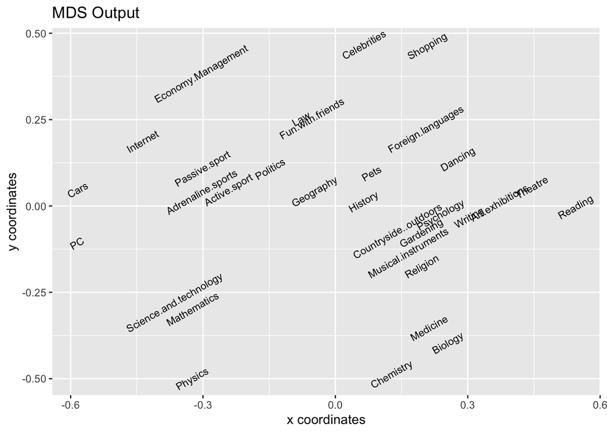

```r
ggplot(as.data.frame(yps_mds),aes(x=x,y=y)) + geom_text(label=rownames(yps_mds),angle=30, size=3) + labs(title="MDS Output", x= "x coordinates",y="y coordinates")
```

We can see that Science and technology interest relates to Mathematics and Physics. Medicine relates to Biology and Chemistry. Reading relates to Theatre and Art exhibitions and Writing.

Let’s try to cluster them to see distinct interest categaries that are closely related to each other:

```r
set.seed(27)
interest_cluster <- kmeans(yps_mds, centers=9)
mds_clusters <- data.frame(interest=names(interest_cluster$cluster), cluster_mds=interest_cluster$cluster) %>% arrange (cluster_mds, interest)
mds_clusters
```

```
##                                      interest cluster_mds
## Mathematics                       Mathematics           1
## Physics                               Physics           1
## Science.and.technology Science.and.technology           1
## Countryside..outdoors   Countryside..outdoors           2
## Gardening                           Gardening           2
## Musical.instruments       Musical.instruments           2
## Psychology                         Psychology           2
## Religion                             Religion           2
## Writing                               Writing           2
## Art.exhibitions               Art.exhibitions           3
## Reading                               Reading           3
## Theatre                               Theatre           3
## Biology                               Biology           4
## Chemistry                           Chemistry           4
## Medicine                             Medicine           4
## Economy.Management         Economy.Management           5
## Fun.with.friends             Fun.with.friends           5
## Law                                       Law           5
## Politics                             Politics           5
## Geography                           Geography           6
## History                               History           6
## Pets                                     Pets           6
## Active.sport                     Active.sport           7
## Adrenaline.sports           Adrenaline.sports           7
## Cars                                     Cars           7
## Internet                             Internet           7
## Passive.sport                   Passive.sport           7
## PC                                         PC           7
## Celebrities                       Celebrities           8
## Shopping                             Shopping           8
## Dancing                               Dancing           9
## Foreign.languages           Foreign.languages           9
```

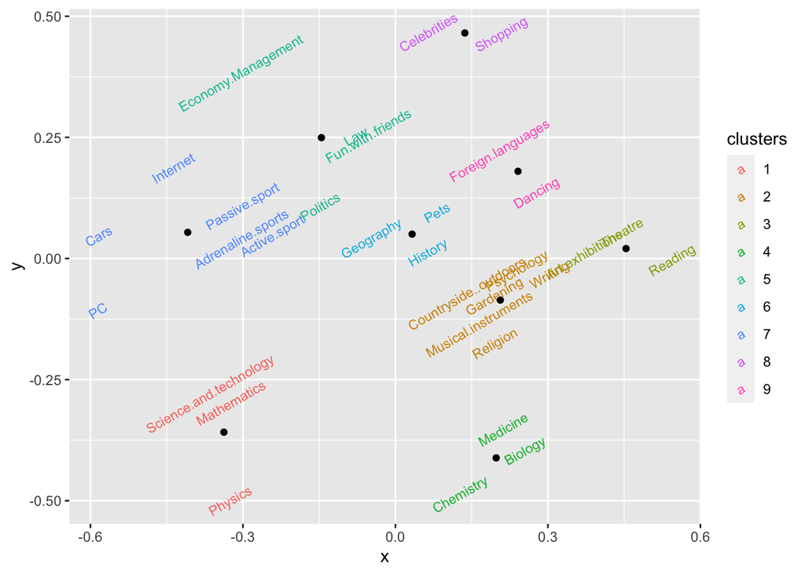

```r
ggplot(data.frame(yps_mds) %>% mutate(clusters=as.factor(interest_cluster$cluster),interests=rownames(yps_mds)),aes(x=x,y=y)) + geom_text(aes(label=interests,color=clusters),angle=30,size=3) + geom_point(data=as.data.frame(interest_cluster$centers),aes(x=x,y=y))
```

The 9 clusters for the young people’s interests can be seen above. This is a good estimation for how different areas of interest relates to each other among young people.

## 0.3 References

https://mef-bda503.github.io/archive/fall17/files/intro_to_ml.html https://stackoverflow.com/questions/54832429/while-using-r-pca-and-plotting-cumulative-variance

## 0.4 Data

https://www.kaggle.com/miroslavsabo/young-people-survey https://www.rdocumentation.org/packages/datasets/versions/3.6.2/topics/esoph